# Lab 5

Aleah Querns

2/21/2022

# The Setup

```r
library(tidyverse)
library(sf)
library(spData)
library(gridExtra)

knitr::opts_knit$set(root.dir = '~/Documents/K-State Year 2/GEOG728/GEOG728_GIT')
```

# The Dataset

```r
data(world)
data(worldbank_df)

world
```

```
## Simple feature collection with 177 features and 10 fields
## Geometry type: MULTIPOLYGON
## Dimension:     XY
## Bounding box:  xmin: -180 ymin: -89.9 xmax: 180 ymax: 83.64513
## Geodetic CRS:  WGS 84
## # A tibble: 177 x 11
##    iso_a2 name_long continent region_un subregion type  area_km2     pop lifeExp
##  * <chr>  <chr>     <chr>     <chr>     <chr>     <chr>    <dbl>   <dbl>   <dbl>
##  1 FJ     Fiji      Oceania   Oceania   Melanesia Sove~   1.93e4  8.86e5    70.0
##  2 TZ     Tanzania  Africa    Africa    Eastern ~ Sove~   9.33e5  5.22e7    64.2
##  3 EH     Western ~ Africa    Africa    Northern~ Inde~   9.63e4 NA         NA
##  4 CA     Canada    North Am~ Americas  Northern~ Sove~   1.00e7  3.55e7    82.0
##  5 US     United S~ North Am~ Americas  Northern~ Coun~   9.51e6  3.19e8    78.8
##  6 KZ     Kazakhst~ Asia      Asia      Central ~ Sove~   2.73e6  1.73e7    71.6
##  7 UZ     Uzbekist~ Asia      Asia      Central ~ Sove~   4.61e5  3.08e7    71.0
##  8 PG     Papua Ne~ Oceania   Oceania   Melanesia Sove~   4.65e5  7.76e6    65.2
##  9 ID     Indonesia Asia      Asia      South-Ea~ Sove~   1.82e6  2.55e8    68.9
## 10 AR     Argentina South Am~ Americas  South Am~ Sove~   2.78e6  4.30e7    76.3
## # ... with 167 more rows, and 2 more variables: gdpPercap <dbl>,
## #   geom <MULTIPOLYGON [°]>
```

```r
worldbank_df
```

```
## # A tibble: 177 x 7
##    name                 iso_a2    HDI urban_pop unemployment pop_growth literacy
##    <chr>                <chr>   <dbl>     <dbl>        <dbl>      <dbl>    <dbl>
##  1 Afghanistan          AF     NA       8609463        NA         3.18      NA
##  2 Angola               AO      0.504  11649562        NA         3.49      66.0
##  3 Albania              AL     NA       1629715        17.5      -0.207     NA
##  4 United Arab Emirates AE     NA       7734365        NA         0.715     NA
##  5 Argentina            AR     NA      39372787         7.27      1.03      NA
##  6 Armenia              AM     NA       1825455        17.5       0.438     NA
##  7 Antarctica           AQ     NA            NA        NA        NA         NA
##  8 French Southern and~ TF     NA            NA        NA        NA         NA
##  9 Australia            AU     NA      20986610         6.08      1.54      NA
## 10 Austria              AT     NA       5630521         5.62      0.731     NA
## # ... with 167 more rows
```

###Q1: Examine the world and worldbank_df datasets. Describe what kind of data objects they are and their general structure and makeup. Then combine these two data objects into a single spatial data object. Does the resulting data object look right?

```r
class(world)
```

```
## [1] "sf"         "tbl_df"     "tbl"        "data.frame"
```

```r
class(worldbank_df)
```

```
## [1] "tbl_df"     "tbl"        "data.frame"
```

```r
str(world)
```

```
## sf [177 x 11] (S3: sf/tbl_df/tbl/data.frame)
##  $ iso_a2   : chr [1:177] "FJ" "TZ" "EH" "CA" ...
##  $ name_long: chr [1:177] "Fiji" "Tanzania" "Western Sahara" "Canada" ...
##  $ continent: chr [1:177] "Oceania" "Africa" "Africa" "North America" ...
##  $ region_un: chr [1:177] "Oceania" "Africa" "Africa" "Americas" ...
##  $ subregion: chr [1:177] "Melanesia" "Eastern Africa" "Northern Africa" "Northern America" ...
##  $ type     : chr [1:177] "Sovereign country" "Sovereign country" "Indeterminate" "Sovereign country" ...
##  $ area_km2 : num [1:177] 19290 932746 96271 10036043 9510744 ...
##  $ pop      : num [1:177] 8.86e+05 5.22e+07 NA 3.55e+07 3.19e+08 ...
##  $ lifeExp  : num [1:177] 70 64.2 NA 82 78.8 ...
##  $ gdpPercap: num [1:177] 8222 2402 NA 43079 51922 ...
##  $ geom     :sfc_MULTIPOLYGON of length 177; first list element: List of 3
##   ..$ :List of 1
##   .. ..$ : num [1:5, 1:2] -180 -180 -180 -180 -180 ...
##   ..$ :List of 1
##   .. ..$ : num [1:9, 1:2] 178 178 177 177 178 ...
##   ..$ :List of 1
##   .. ..$ : num [1:8, 1:2] 180 180 179 179 179 ...
##   ..- attr(*, "class")= chr [1:3] "XY" "MULTIPOLYGON" "sfg"
##  - attr(*, "sf_column")= chr "geom"
##  - attr(*, "agr")= Factor w/ 3 levels "constant","aggregate",..: NA NA NA NA NA NA NA NA NA NA
##   ..- attr(*, "names")= chr [1:10] "iso_a2" "name_long" "continent" "region_un" ...
```

```r
str(worldbank_df)
```

```
## tibble [177 x 7] (S3: tbl_df/tbl/data.frame)
##  $ name        : chr [1:177] "Afghanistan" "Angola" "Albania" "United Arab Emirates" ...
##  $ iso_a2      : chr [1:177] "AF" "AO" "AL" "AE" ...
##  $ HDI         : num [1:177] NA 0.504 NA NA NA NA NA NA NA NA ...
##  $ urban_pop   : num [1:177] 8609463 11649562 1629715 7734365 39372787 ...
##  $ unemployment: num [1:177] NA NA 17.49 NA 7.27 ...
##  $ pop_growth  : num [1:177] 3.183 3.485 -0.207 0.715 1.033 ...
##  $ literacy    : num [1:177] NA 66 NA NA NA ...
```

```r
setdiff(world$name_long, worldbank_df$name)
```

```
## [1] "Côte d'Ivoire"         "Republic of the Congo" "eSwatini"
```

```r
worldbank_df$name<-gsub(pattern = "Cote d'Ivoire", replacement= "Côte d'Ivoire", worldbank_df$name)

worldbank_df$name<-gsub(pattern = "Swaziland", replacement= "eSwatini", worldbank_df$name)

worldbank_df$name<-gsub(pattern = "Republic of Congo", replacement= "Republic of the Congo", worldbank_df$name)


worldfull<-merge(world, worldbank_df, by.x ="name_long", by.y= "name", na.rm=F)

colSums(is.na(worldfull))
```

```
##    name_long     iso_a2.x    continent    region_un    subregion         type
##            0            2            0            0            0            0
##     area_km2          pop      lifeExp    gdpPercap     iso_a2.y          HDI
##            0           10           10           17            3          130
##    urban_pop unemployment   pop_growth     literacy     geometry
##            9           63            9          143            0
```

*“world”*

*“worldbank_df”*

**At first, the datasets weren’t merging correctly due to small differences in country names between the two. To correct this, I used gsub to correct the errors in the worldbank_df**

### Q2: Make some basic (non-spatial) plots to explore differences in urban population and literacy across countries.

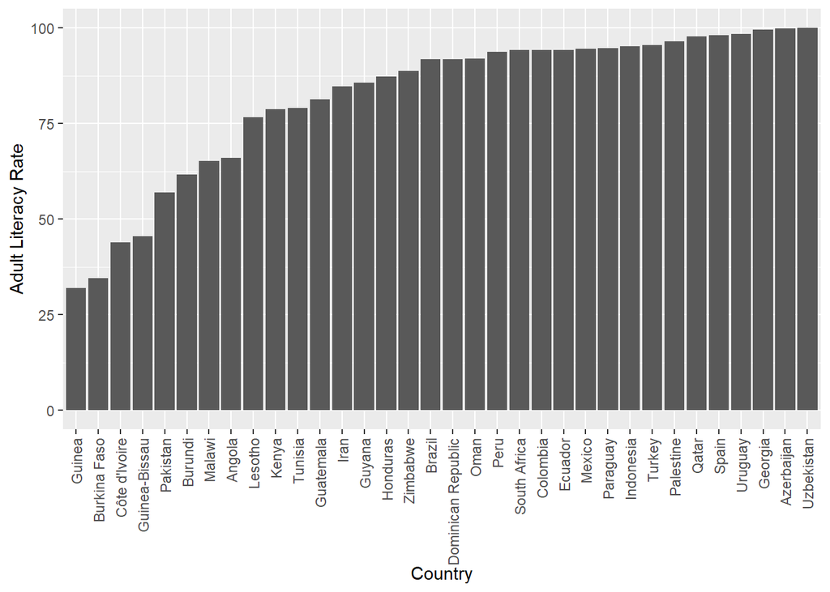

```r
worldfull%>%
  filter(!is.na(literacy), literacy !=0)%>%
ggplot(aes(x=reorder(name_long, literacy), y=literacy)) +
  geom_bar(stat = 'identity')+
  theme(axis.text.x = element_text(angle = 90, vjust = 0.5, hjust=1))+
  xlab ("Country") +
  ylab("Adult Literacy Rate")
```

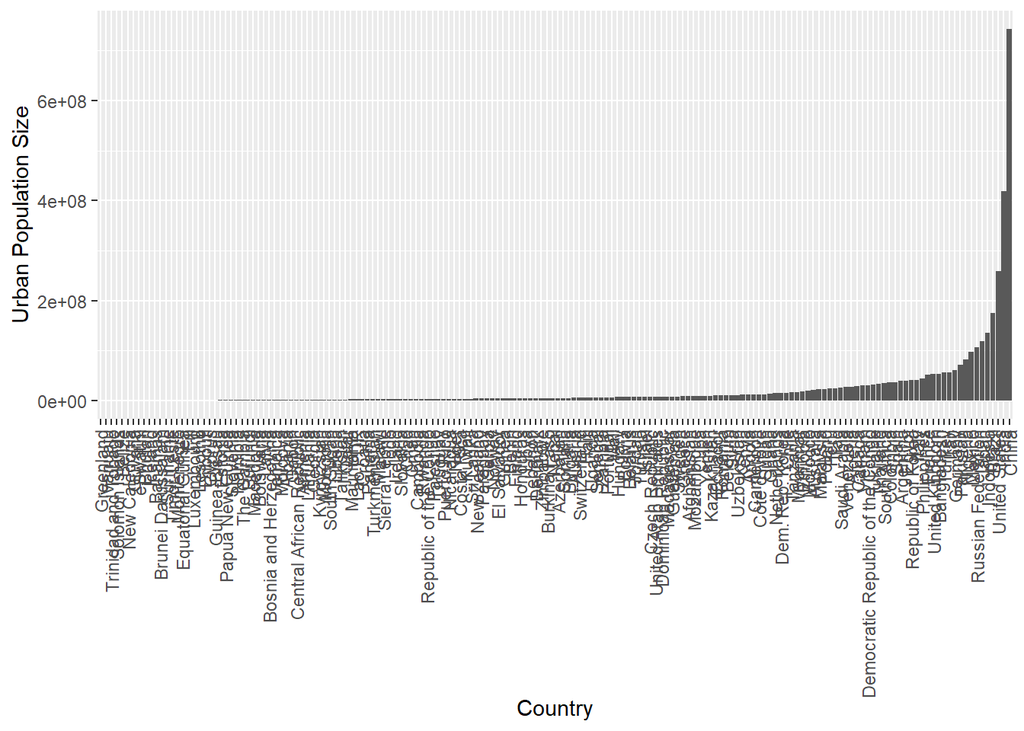

```r
worldfull%>%
  filter(!is.na(urban_pop), urban_pop !=0)%>%
ggplot(aes(x=reorder(name_long, urban_pop), y=urban_pop)) +
  geom_bar(stat = 'identity')+
  theme(axis.text.x = element_text(angle = 90, vjust = 0.5, hjust=1))+
  xlab ("Country") +
  ylab("Urban Population Size")
```

*As always, these plots are hard to view because of the number of countries, so it’s best to view them in another window*

### Q3: Now make some maps to explore urban population and literacy across countries.

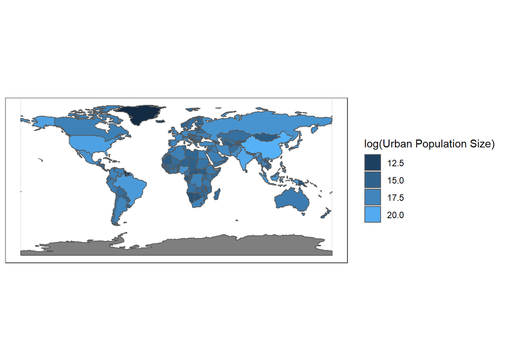

```r
ggplot(worldfull)+
  geom_sf(aes(fill=log(urban_pop))) +
  theme_bw()+
  guides(fill=guide_legend(title="log(Urban Population Size)"))
```

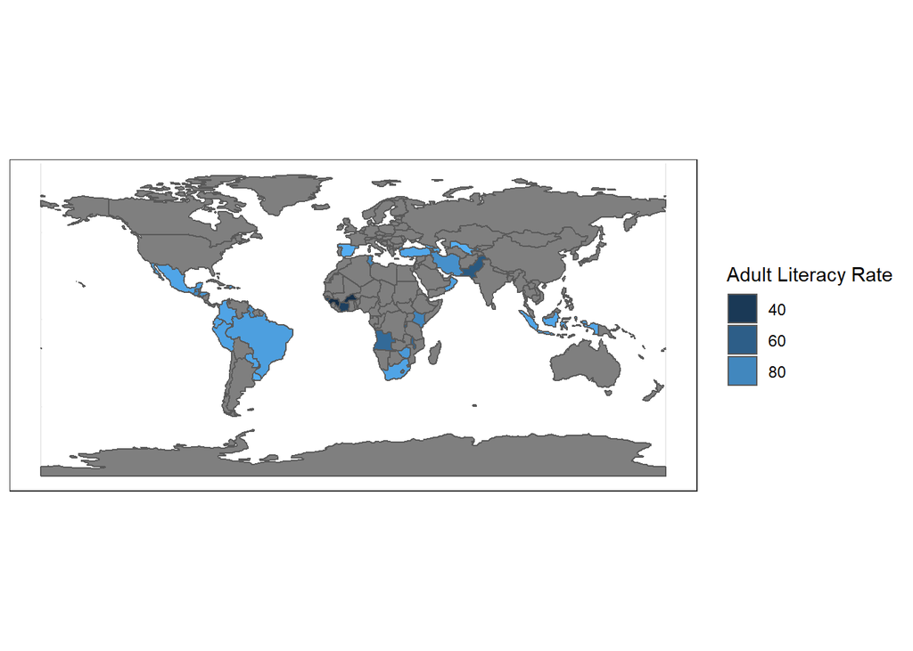

```r
ggplot(worldfull)+
  geom_sf(aes(fill=literacy)) +
  theme_bw()+
  guides(fill=guide_legend(title="Adult Literacy Rate"))
```

*Interestingly, it seems like most countries aren’t providing data on literacy rates*

### Q4: Make some basic (non-spatial) plots to explore differences in urban population and literacy across continents.

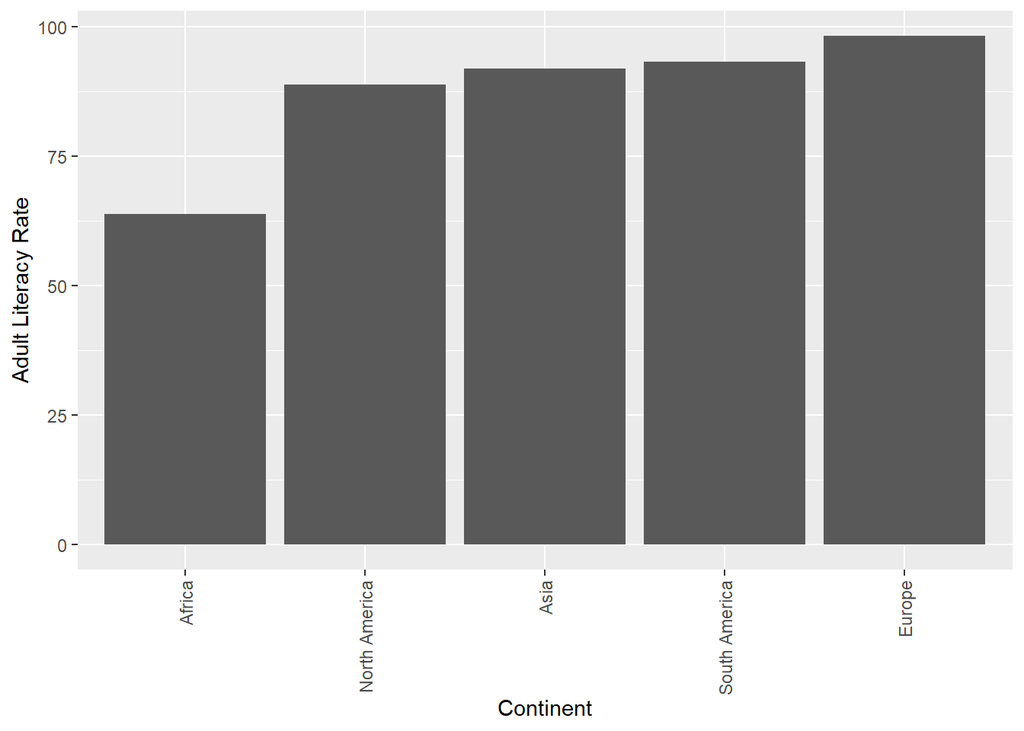

```r
worldfull%>%
  filter(!is.na(literacy), literacy !=0)%>%
  group_by(continent)%>%
  summarise(literacy_mean = mean(literacy)) %>%
ggplot(aes(x=reorder(continent, literacy_mean), y=literacy_mean)) +
  geom_bar(stat = 'identity')+
  theme(axis.text.x = element_text(angle = 90, vjust = 0.5, hjust=1))+
  xlab ("Continent") +
  ylab("Adult Literacy Rate")
```

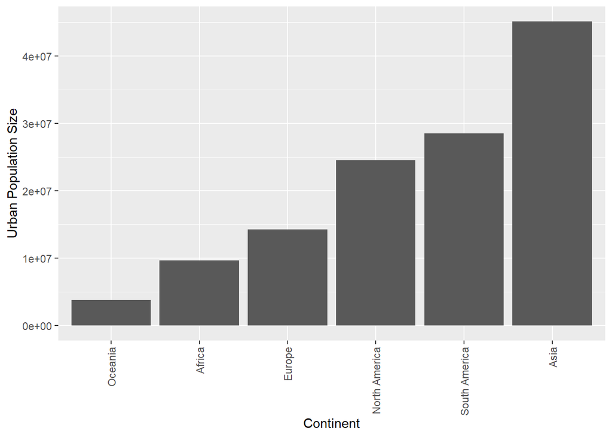

```r
worldfull%>%
  filter(!is.na(urban_pop), urban_pop !=0)%>%
  group_by(continent)%>%
  summarise(urban_pop_mean = mean(urban_pop)) %>%
ggplot(aes(x=reorder(continent, urban_pop_mean), y=urban_pop_mean)) +
  geom_bar(stat = 'identity')+
  theme(axis.text.x = element_text(angle = 90, vjust = 0.5, hjust=1))+
  xlab ("Continent") +
  ylab("Urban Population Size")
```

### Q5: Now make some maps to explore differences in urban population and literacy across continents. Change to a different, projected coordinate system for these maps.

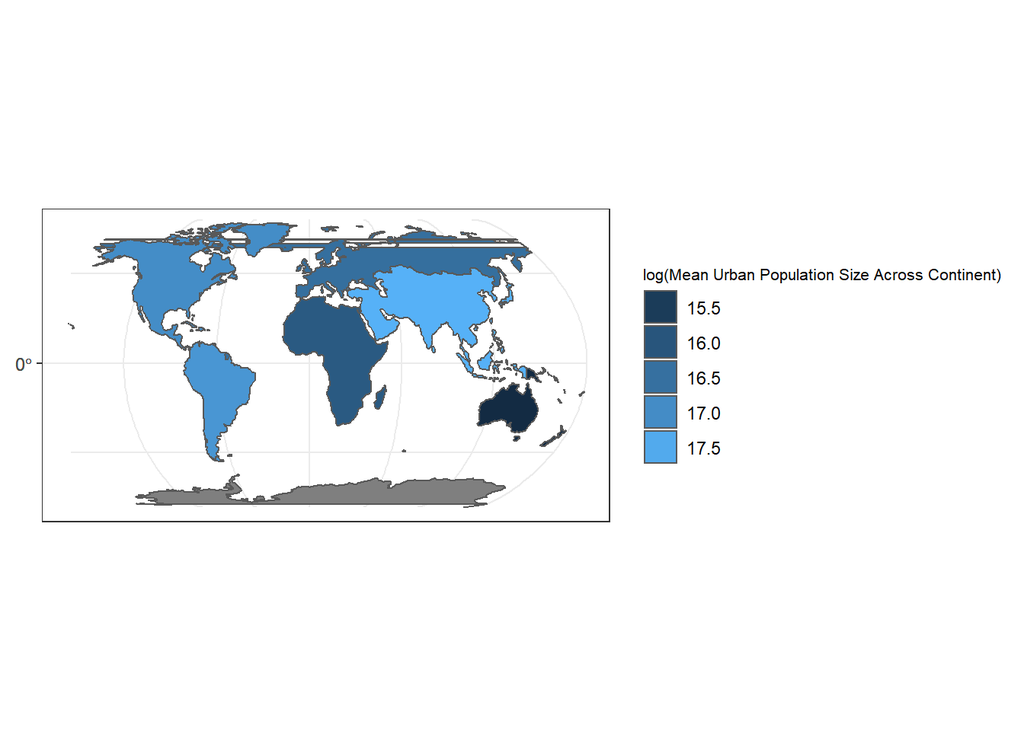

```r
worldfullproj<-st_make_valid(st_transform(worldfull, "+proj=natearth +lon_0=1 +datum=WGS84 +units=m +no_defs"))

worldfullproj %>%
  group_by(continent) %>%
  summarise(urban_pop_mean = mean(urban_pop, na.rm=TRUE)) %>%
ggplot()+
  geom_sf(aes(fill=log(urban_pop_mean))) +
  theme_bw()+
  guides(fill=guide_legend(title="log(Mean Urban Population Size Across Continent)"))+
  theme(legend.title = element_text(size = 8))
```

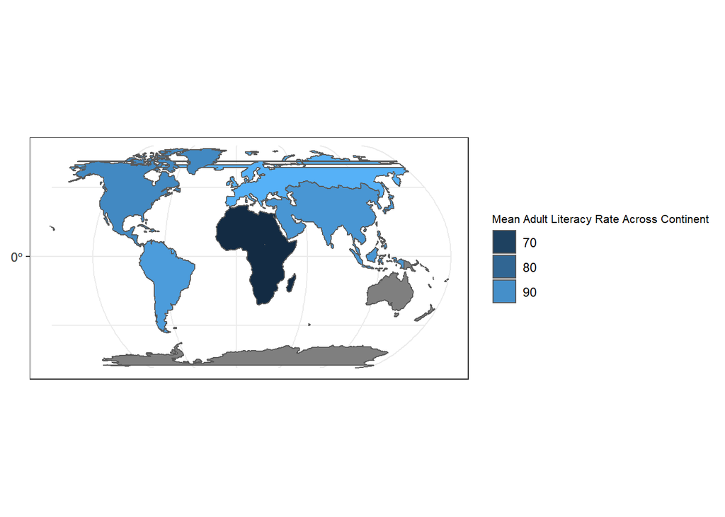

```r
worldfullproj %>%
  group_by(continent) %>%
  summarise(lit_mean = mean(literacy, na.rm=TRUE)) %>%
ggplot()+
  geom_sf(aes(fill=lit_mean)) +
  theme_bw()+
  guides(fill=guide_legend(title="Mean Adult Literacy Rate Across Continent"))+
  theme(legend.title = element_text(size = 8))
```